# Dzikie wysypiska w Łodzi. Wyniki badań

Remek

2022-07-13

## Wyniki w zakresie

- Liczby wpisów na mapę dzikich wysypisk: **183 wpisy**
- Liczby ochotniczek / ochotników wysyłających wpisy: **54 osoby**
- Rozmieszczenia dzikich wysypisk: **najwięcej wpisów z Widzewa, najbardziej zaśmiecone Śródmieście**
- Cech dzikich wysypisk: znamy je dla **27%** wpisów (50 z 183).

Stan badań na 2022-06-30

## Liczba wpisów dziennie

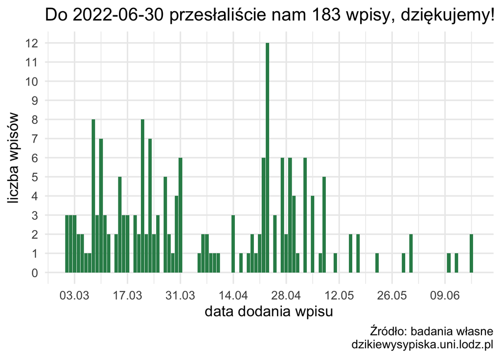

## Liczba wpisów miesięcznie

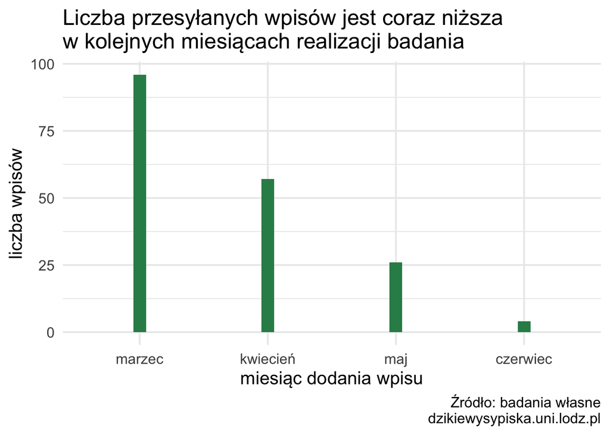

## Liczba ochotniczek / ochotników w czasie

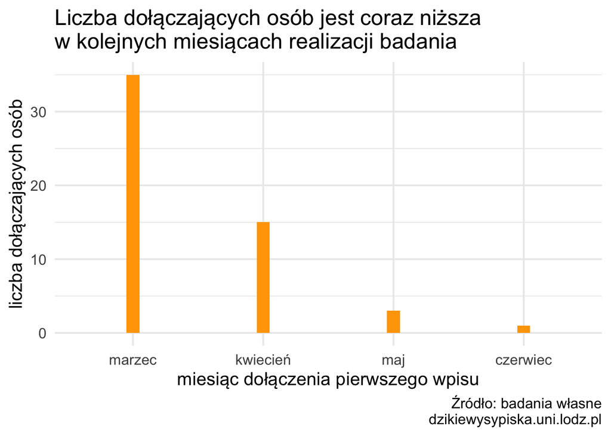

Łącznie wpisy na mapę dzikich wysypisk przesłały **54 osoby**.

## Aktywność ochotników / ochotniczek

Wszystkie nazwy ochotników ujednoliciłem do małych liter. Usunąłem spacje na początku i na końcu nazw. To pozwoliło liczyć nazwy wpisane np. “sebastian33444” i “Sebastian33444” jako to samo.

| volunteer_id | n |
| --- | --- |
| katarzyna wasilewska | 16 |
| pkrupnik | 15 |
| rmo | 15 |
| hpruszyn | 14 |
| alex1313 | 13 |
| email_dzikiewysypiska | 11 |
| kraterek | 9 |
| ktk | 8 |
| anna_krzynowek | 5 |
| darkerone | 5 |
| langel | 5 |
| uffo7 | 4 |
| kolija | 3 |
| quks | 3 |
| radkel | 3 |
| taranah | 3 |
| twardy | 3 |
| zwiedzamłódź | 3 |
| alex | 2 |
| efem | 2 |
| gargl | 2 |
| jul_woj | 2 |
| maciej | 2 |
| ms1996 | 2 |
| radosław antosik | 2 |
| sebastian33444 | 2 |
| tooomasz | 2 |
| ainka | 1 |
| alexxx19 | 1 |
| atom | 1 |
| bogusia | 1 |
| dim79 | 1 |
| ezamar | 1 |
| j13 | 1 |
| jerzy1956 | 1 |
| jmp | 1 |
| juha | 1 |
| juliaróża | 1 |
| juliaz | 1 |
| kacperka1 | 1 |
| kasia chojnacka | 1 |
| katarzyna | 1 |
| magpas | 1 |
| małgo | 1 |
| małgorzata | 1 |
| nittka969 | 1 |
| noyes | 1 |
| nukazet | 1 |
| ps | 1 |
| romek1076 | 1 |
| sejti | 1 |
| sierra | 1 |
| tomektramwaj | 1 |
| ula urszula | 1 |

Ile osób zrobiło jeden wpis? Ile więcej?

Mamy dużo osób, które zrobiły mało wpisów, a mało takich które zrobiły dużo.

To jest też typowe np. w użytkowaniu mediów społecznościowych (mało osób ma wysoką aktywność a dużą ma małą).

| liczba_wpis | liczba_ochotnik |
| --- | --- |
| 1 | 27 |
| 2 | 9 |
| 3 | 6 |
| 4 | 1 |
| 5 | 3 |
| 8 | 1 |
| 9 | 1 |
| 11 | 1 |
| 13 | 1 |
| 14 | 1 |
| 15 | 2 |
| 16 | 1 |

Zobaczymy jeszcze, czy ilość wpisów jest powiązana z tym, jak długo ochotnik jest z nami. Biorę datę zatwierdzaną przez ochotnika.

Liczę różnicę dat jako ostatnia_data - pierwsza_data + 1. Czyli 1 dzień oznacza, że ochotnik przesłał wpisy tylko jednego dnia.

| volunteer_id | liczba_wpis | pierwszy_ostatni_wpis_ile_dni |
| --- | --- | --- |
| katarzyna wasilewska | 16 | 96 |
| pkrupnik | 15 | 51 |
| rmo | 15 | 57 |
| hpruszyn | 14 | 11 |
| alex1313 | 13 | 16 |
| email_dzikiewysypiska | 11 | 49 |
| kraterek | 9 | 28 |
| ktk | 8 | 101 |
| anna_krzynowek | 5 | 7 |
| darkerone | 5 | 44 |
| langel | 5 | 2 |
| uffo7 | 4 | 28 |
| kolija | 3 | 1 |
| quks | 3 | 1 |
| radkel | 3 | 1 |
| taranah | 3 | 24 |
| twardy | 3 | 2 |
| zwiedzamłódź | 3 | 1 |
| alex | 2 | 26 |
| efem | 2 | 4 |
| gargl | 2 | 19 |
| jul_woj | 2 | 1 |
| maciej | 2 | 19 |
| ms1996 | 2 | 1 |
| radosław antosik | 2 | 1 |
| sebastian33444 | 2 | 37 |
| tooomasz | 2 | 1 |
| ainka | 1 | 1 |
| alexxx19 | 1 | 1 |
| atom | 1 | 1 |
| bogusia | 1 | 1 |
| dim79 | 1 | 1 |
| ezamar | 1 | 1 |
| j13 | 1 | 1 |
| jerzy1956 | 1 | 1 |
| jmp | 1 | 1 |
| juha | 1 | 1 |
| juliaróża | 1 | 1 |
| juliaz | 1 | 1 |
| kacperka1 | 1 | 1 |
| kasia chojnacka | 1 | 1 |
| katarzyna | 1 | 1 |
| magpas | 1 | 1 |
| małgo | 1 | 1 |
| małgorzata | 1 | 1 |
| nittka969 | 1 | 1 |
| noyes | 1 | 1 |
| nukazet | 1 | 1 |
| ps | 1 | 1 |
| romek1076 | 1 | 1 |
| sejti | 1 | 1 |
| sierra | 1 | 1 |
| tomektramwaj | 1 | 1 |
| ula urszula | 1 | 1 |

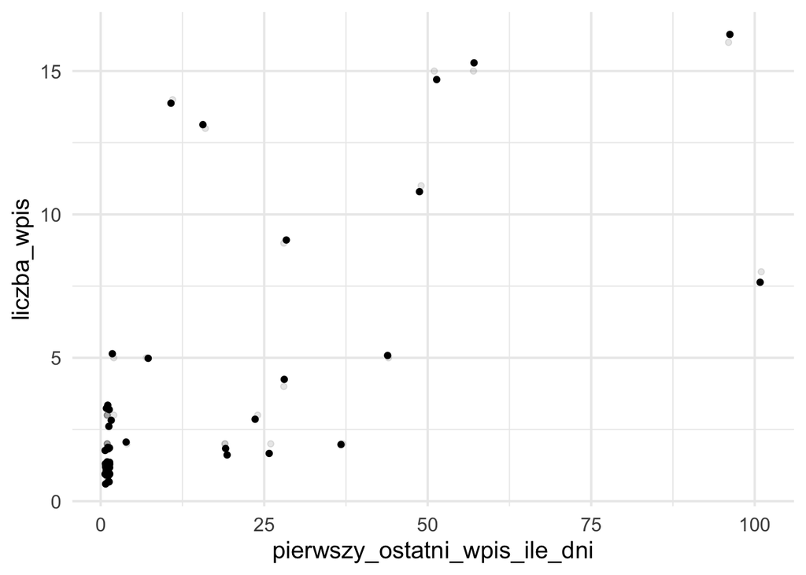

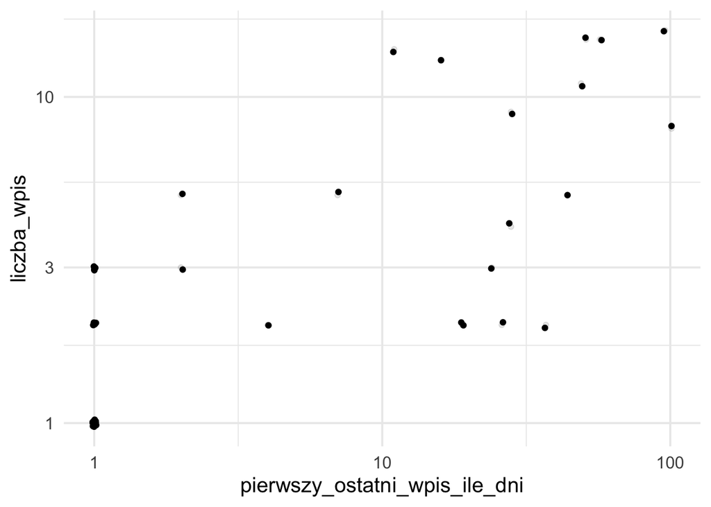

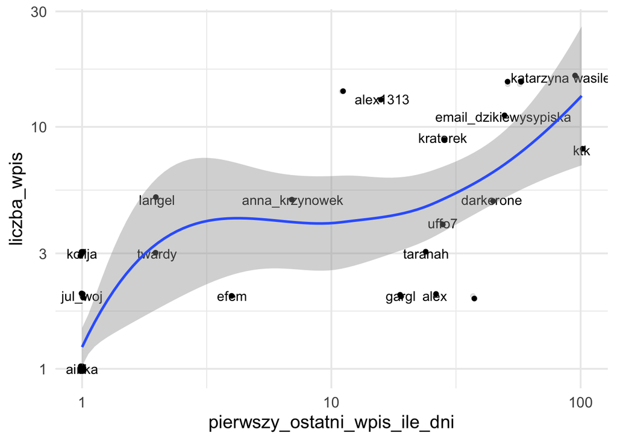

Ci co są dłużej niż 10 dni mają więcej wpisów?

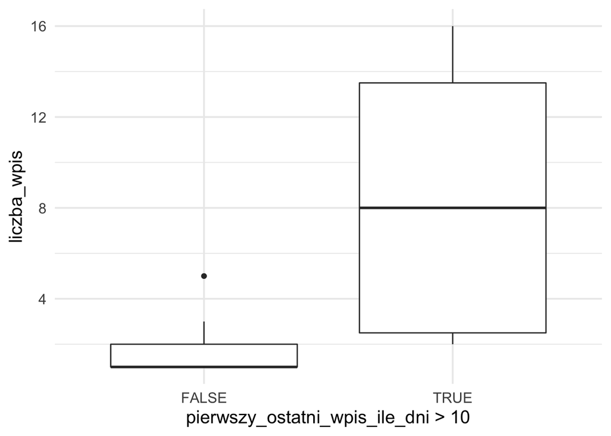

To są nierówne grupy. Tych, co są dłużej mamy znacznie mniej.

```
## pierwszy_ostatni_wpis_ile_dni > 10
## FALSE  TRUE
##    39    15
```

```
##
##  Spearman's rank correlation rho
##
## data:  volunt_difftime$pierwszy_ostatni_wpis_ile_dni and volunt_difftime$liczba_wpis
## S = 5140.3, p-value = 2.453e-13
## alternative hypothesis: true rho is not equal to 0
## sample estimates:
##       rho
## 0.8040663
```

Korelacja wychodzi 0.8040663 czyli tak, im dłużej ochotnik jest z nami tym ma więcej wpisów.

## Rozmieszczenie – mapa

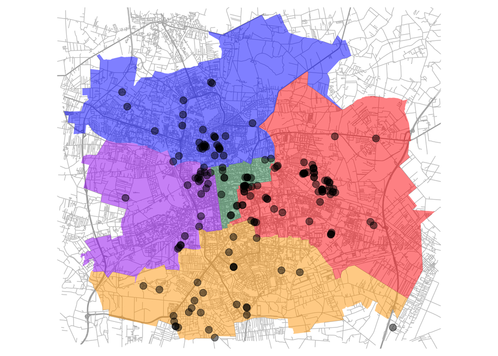

Jeden punkt na mapie oznacza jeden wpis. Łącznie 172 punkty, 94% z 183 wpisów.

## Rozmieszczenie – liczba w dzielnicach

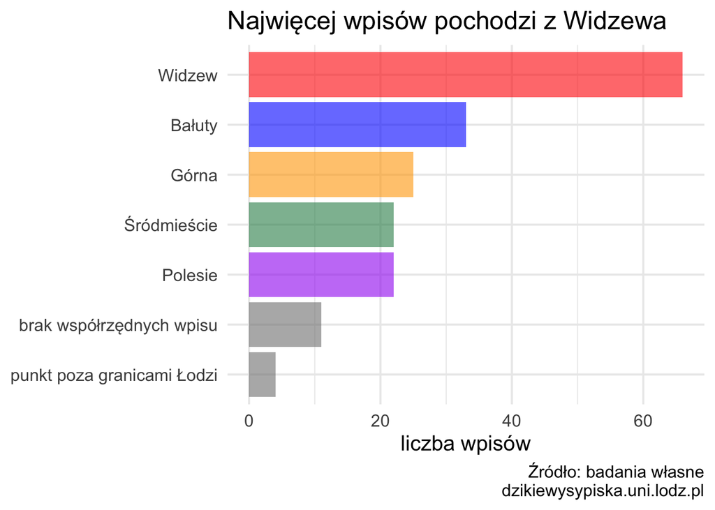

## Rozmieszczenie – liczba w dzielnicach w odniesieniu do powierzchni

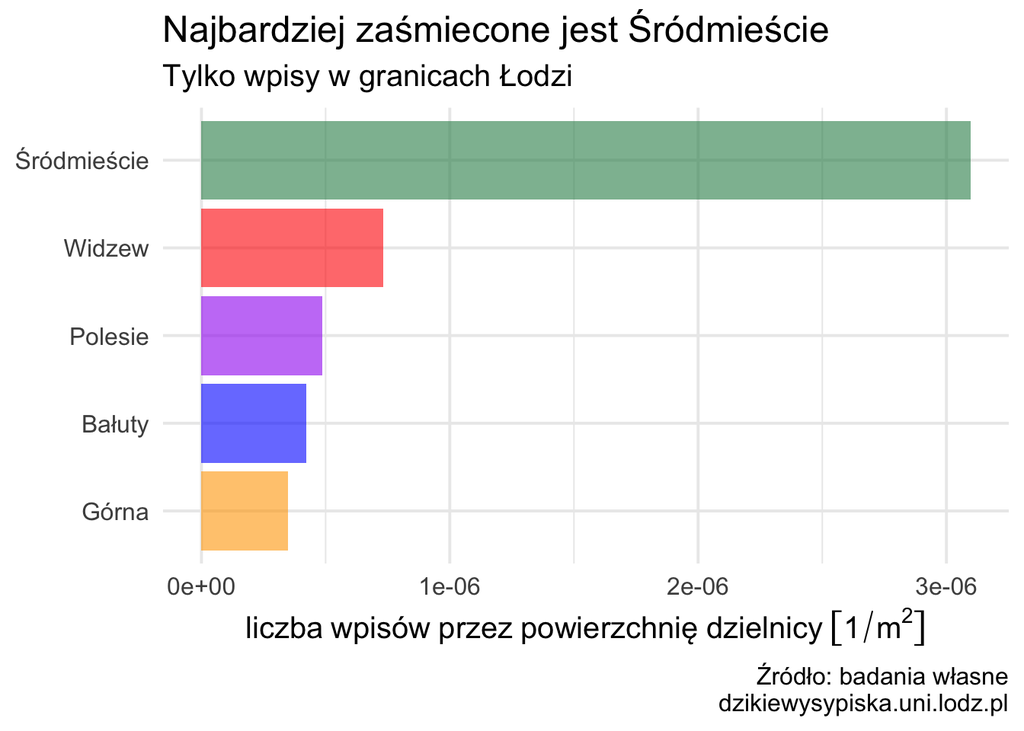

## Cechy dzikich wysypisk – ilość informacji

| Podano informację o wysypisku | n | % |
| --- | --- | --- |
| Nie | 133 | 73 |
| Tak | 50 | 27 |
| SUMA | 183 | 100 |

O ile nie wskazano inaczej, **cechy wysypisk dotyczą 50 wpisów**.

## Cechy dzikich wysypisk – powierzchnia

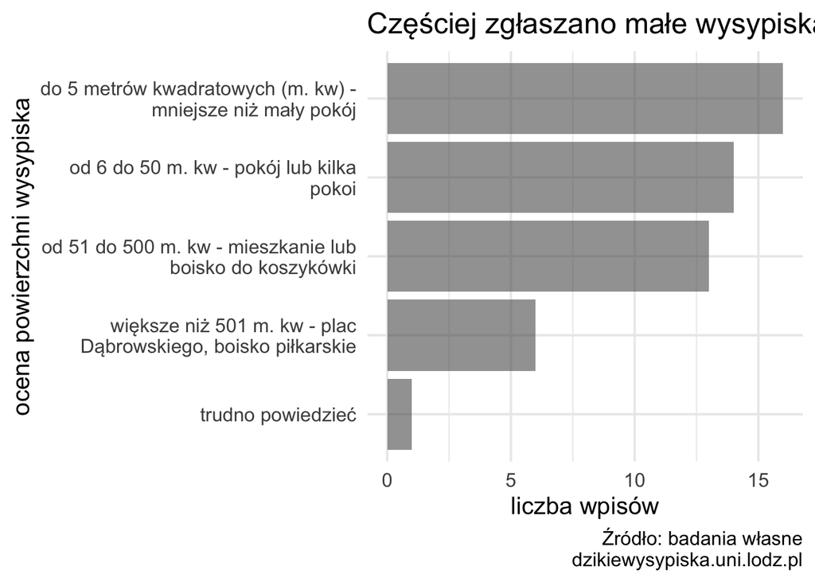

## Cechy dzikich wysypisk – charakter

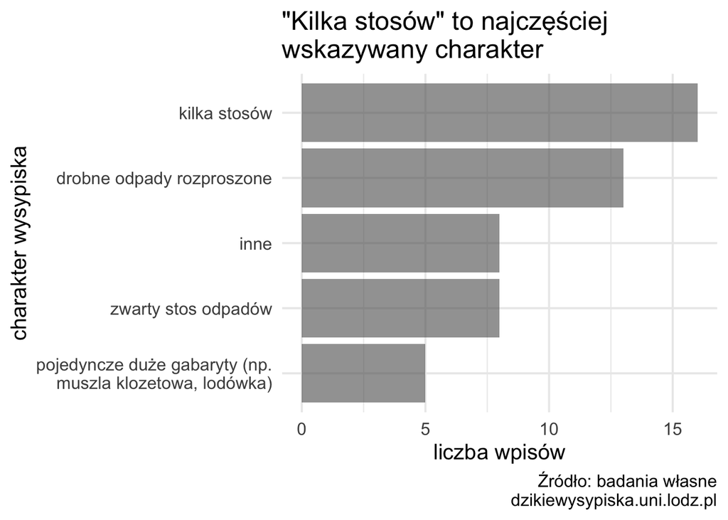

## Cechy dzikich wysypisk – miejsce

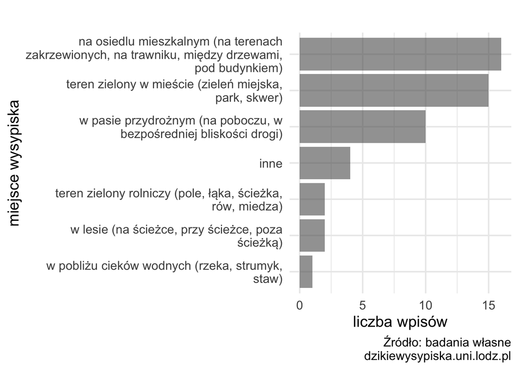

## Cechy dzikich wysypisk – rodzaje odpadów

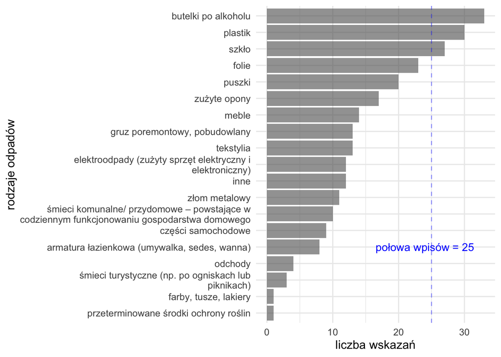

Pytanie wielokrotnego wyboru, odpowiedzi nie sumują się do 50 wpisów.

## Cechy dzikich wysypisk – widoczność

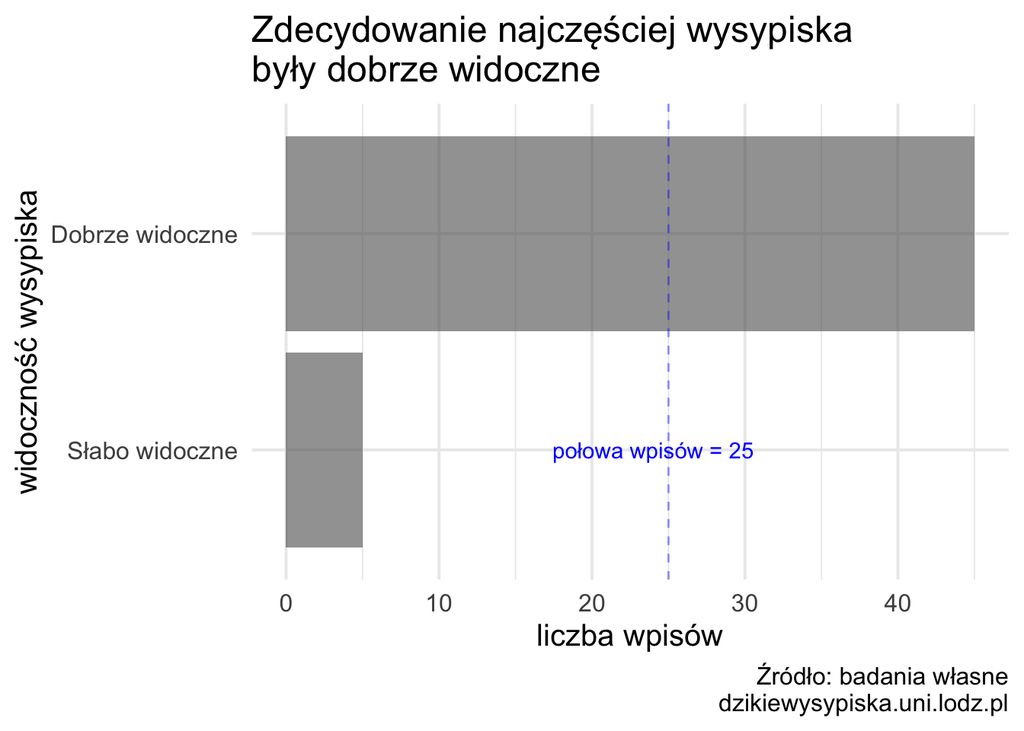

Nikt nie wskazał, że wysypisko jest “niewidoczne (ukryte)”.

## Cechy dzikich wysypisk – czas powstania

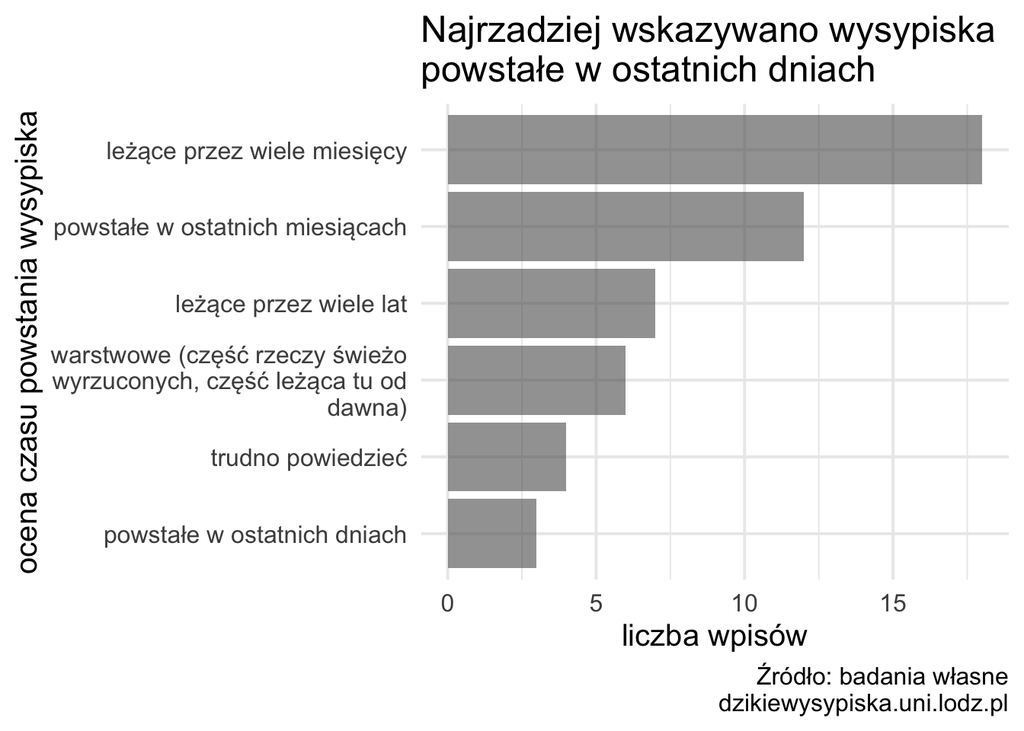